# Lab-11: Assignment

Author

Brian Kwon

## Problem 1-2 will be answered using the “Artists.csv” data set.

### Please find the “Artists.csv” data set in the Canvas-> Lab 10 folder.

Meanwhile, this is how you can retrieve Spotify Data:

Spotify’s API gives you the ability to extract several audio features of a song. The available features that also have been used for this analysis are: https://medium.com/@boplantinga/what-do-spotifys-audio-features-tell-us-about-this-year-s-eurovision-song-contest-66ad188e112a

The first step was registering my application in the API Website(https://developer.spotify.com/documentation/web-api/) and getting the keys (Client ID and Client Secret) for future requests. The Spotify Web API has different URIs (Uniform Resource Identifiers) to access playlists, artists, or tracks information.

I extracted all the audio features for 3 musicians Taylor Swift, John Legend and Beyonce. But we are only going to use selected features.

(If you like to use this data for your Final Project, you are more than welcome to :), but please extract more features from more musicians)

```r
library(Rspotify)
library(httr)
library(jsonlite)
library(spotifyr)#spotifyr is an R wrapper for pulling track audio features and other information from Spotify’s Web API in bulk.


get_spotify_access_token(client_id = "8a556a04a8634ac99c1c317c336cdcaa",
                         client_secret = "2c681e6bf45b450396d1e5d2487e5f71")

Sys.setenv(SPOTIFY_CLIENT_ID = "8a556a04a8634ac99c1c317c336cdcaa")
Sys.setenv(SPOTIFY_CLIENT_SECRET = "2c681e6bf45b450396d1e5d2487e5f71")

access_token = get_spotify_access_token()


Taylor_Swift <- get_artist_audio_features("Taylor Swift")
John_Legend <- get_artist_audio_features("John Legend")
Beyonce <- get_artist_audio_features("Beyonce")

## You can also access the variables by indexes, but the names are here to see what I'm retreiving

Taylor_Swift_A <-data.frame(Taylor_Swift$artist_name,Taylor_Swift$valence,
                            Taylor_Swift$danceability,Taylor_Swift$energy,Taylor_Swift$loudness,
                            Taylor_Swift$speechiness,Taylor_Swift$acousticness,Taylor_Swift$liveness,
                            Taylor_Swift$tempo,Taylor_Swift$track_name, Taylor_Swift$album_name,Taylor_Swift$album_release_year)
colnames(Taylor_Swift_A) <- c("artist_name","Valence","danceability","energy",
                              "loudness","speechiness","acousticness","liveness",
                              "tempo","track_name","album_name","album_release_year")
head(Taylor_Swift_A)


John_Legend_A <-data.frame(John_Legend$artist_name,John_Legend$valence,
                            John_Legend$danceability,John_Legend$energy,John_Legend$loudness,
                            John_Legend$speechiness,John_Legend$acousticness,John_Legend$liveness,
                            John_Legend$tempo,John_Legend$track_name, John_Legend$album_name,John_Legend$album_release_year)

colnames(John_Legend_A) <- c("artist_name","alence","danceability","energy",
                              "loudness","speechiness","acousticness","liveness",
                              "tempo","track_name","album_name","album_release_year")
head(John_Legend_A)


Beyonce_A <-data.frame(Beyonce$artist_name,Beyonce$valence,
                       Beyonce$danceability,Beyonce$energy,Beyonce$loudness,
                       Beyonce$speechiness,Beyonce$acousticness,Beyonce$liveness,
                       Beyonce$tempo,Beyonce$track_name, Beyonce$album_name, Beyonce$album_release_year)

colnames(Beyonce_A) <- c("artist_name","Valence","danceability","energy",
                             "loudness","speechiness","acousticness","liveness",
                             "tempo","track_name","album_name","album_release_year")
head(Beyonce_A)
```

'BQDT2--vhQ9kHPaKD6fWUwhBNO_J681JDZgkvvsLCOp4S83iRT5z9TkREcEbTEwEN6SyKNGuvb6XhXt0jn6of3aixeeQMn7rQNDdzEP4a5ZSlny4F0Q'

A data.frame: 6 × 12

|  | artist_name <chr> | Valence <dbl> | danceability <dbl> | energy <dbl> | loudness <dbl> | speechiness <dbl> | acousticness <dbl> | liveness <dbl> | tempo <dbl> | track_name <chr> | album_name <chr> | album_release_year <dbl> |
| --- | --- | --- | --- | --- | --- | --- | --- | --- | --- | --- | --- | --- |
| 1 | Taylor Swift | 0.685 | 0.757 | 0.610 | -4.840 | 0.0327 | 0.009420 | 0.3670 | 116.998 | Welcome To New York (Taylor's Version) | 1989 (Taylor's Version) [Deluxe] | 2023 |
| 2 | Taylor Swift | 0.701 | 0.733 | 0.733 | -5.376 | 0.0670 | 0.088500 | 0.1680 | 96.057 | Blank Space (Taylor's Version) | 1989 (Taylor's Version) [Deluxe] | 2023 |
| 3 | Taylor Swift | 0.305 | 0.511 | 0.822 | -4.785 | 0.0397 | 0.000421 | 0.0899 | 94.868 | Style (Taylor's Version) | 1989 (Taylor's Version) [Deluxe] | 2023 |
| 4 | Taylor Swift | 0.206 | 0.545 | 0.885 | -5.968 | 0.0447 | 0.000537 | 0.3850 | 92.021 | Out Of The Woods (Taylor's Version) | 1989 (Taylor's Version) [Deluxe] | 2023 |
| 5 | Taylor Swift | 0.520 | 0.588 | 0.721 | -5.579 | 0.0317 | 0.000656 | 0.1310 | 96.997 | All You Had To Do Was Stay (Taylor's Version) | 1989 (Taylor's Version) [Deluxe] | 2023 |
| 6 | Taylor Swift | 0.917 | 0.636 | 0.808 | -5.693 | 0.0729 | 0.012100 | 0.3590 | 160.058 | Shake It Off (Taylor's Version) | 1989 (Taylor's Version) [Deluxe] | 2023 |

A data.frame: 6 × 12

|  | artist_name <chr> | alence <dbl> | danceability <dbl> | energy <dbl> | loudness <dbl> | speechiness <dbl> | acousticness <dbl> | liveness <dbl> | tempo <dbl> | track_name <chr> | album_name <chr> | album_release_year <dbl> |
| --- | --- | --- | --- | --- | --- | --- | --- | --- | --- | --- | --- | --- |
| 1 | John Legend | 0.296 | 0.470 | 0.327 | -7.260 | 0.0402 | 0.897 | 0.115 | 62.915 | Honey - Piano Version | LEGEND (Solo Piano Version) | 2023 |
| 2 | John Legend | 0.550 | 0.589 | 0.596 | -5.042 | 0.0560 | 0.484 | 0.210 | 123.277 | Nervous - Piano Version | LEGEND (Solo Piano Version) | 2023 |
| 3 | John Legend | 0.610 | 0.601 | 0.508 | -5.313 | 0.0348 | 0.842 | 0.127 | 111.662 | All She Wanna Do - Piano Version | LEGEND (Solo Piano Version) | 2023 |
| 4 | John Legend | 0.579 | 0.398 | 0.538 | -5.073 | 0.0607 | 0.673 | 0.338 | 180.935 | Strawberry Blush - Piano Version | LEGEND (Solo Piano Version) | 2023 |
| 5 | John Legend | 0.434 | 0.438 | 0.265 | -6.708 | 0.0301 | 0.885 | 0.110 | 81.354 | Rounds - Piano Version | LEGEND (Solo Piano Version) | 2023 |
| 6 | John Legend | 0.615 | 0.478 | 0.391 | -5.556 | 0.0363 | 0.841 | 0.179 | 120.242 | Splash - Piano Version | LEGEND (Solo Piano Version) | 2023 |

A data.frame: 6 × 12

|  | artist_name <chr> | Valence <dbl> | danceability <dbl> | energy <dbl> | loudness <dbl> | speechiness <dbl> | acousticness <dbl> | liveness <dbl> | tempo <dbl> | track_name <chr> | album_name <chr> | album_release_year <dbl> |
| --- | --- | --- | --- | --- | --- | --- | --- | --- | --- | --- | --- | --- |
| 1 | Beyonc'e | 0.136 | 0.554 | 0.535 | -8.959 | 0.1860 | 0.061600 | 0.1240 | 105.865 | I'M THAT GIRL | RENAISSANCE | 2022 |
| 2 | Beyonc'e | 0.367 | 0.556 | 0.630 | -8.150 | 0.1020 | 0.000828 | 0.1550 | 149.147 | COZY | RENAISSANCE | 2022 |
| 3 | Beyonc'e | 0.464 | 0.545 | 0.641 | -6.398 | 0.0998 | 0.004530 | 0.1710 | 121.892 | ALIEN SUPERSTAR | RENAISSANCE | 2022 |
| 4 | Beyonc'e | 0.642 | 0.780 | 0.689 | -5.668 | 0.1410 | 0.036800 | 0.0698 | 115.042 | CUFF IT | RENAISSANCE | 2022 |
| 5 | Beyonc'e | 0.587 | 0.903 | 0.519 | -9.151 | 0.2600 | 0.281000 | 0.1550 | 114.991 | ENERGY (feat. Beam) | RENAISSANCE | 2022 |
| 6 | Beyonc'e | 0.864 | 0.693 | 0.887 | -5.039 | 0.0795 | 0.058100 | 0.2700 | 114.942 | BREAK MY SOUL | RENAISSANCE | 2022 |

You can download the data set “Artists.csv” from Canvas->“Midterm” Folder.

```r
artists = read.csv("Artists.csv")
```

## Problem 1: Hypothesis Testing - part 1

Data Science Question: Does the average “speechiness” is larger for Taylor Swift than that of John Legend ?

1. Perform EDA (Exploratory Data Analysis) using some Data Visualizations.

```r
ts = artists[artists$artist_name == "Taylor Swift",]
jl = artists[artists$artist_name == "John Legend",]
```

```r
colSums(is.na(ts))
colSums(is.na(jl))
```

**X**

0

**artist_name**

0

**Valence**

0

**danceability**

0

**energy**

0

**loudness**

0

**speechiness**

0

**acousticness**

0

**liveness**

0

**tempo**

0

**track_name**

0

**album_name**

0

**album_release_year**

0

**X**

0

**artist_name**

0

**Valence**

0

**danceability**

0

**energy**

0

**loudness**

0

**speechiness**

0

**acousticness**

0

**liveness**

0

**tempo**

0

**track_name**

0

**album_name**

0

**album_release_year**

0

There is no NA values in the dataframe.

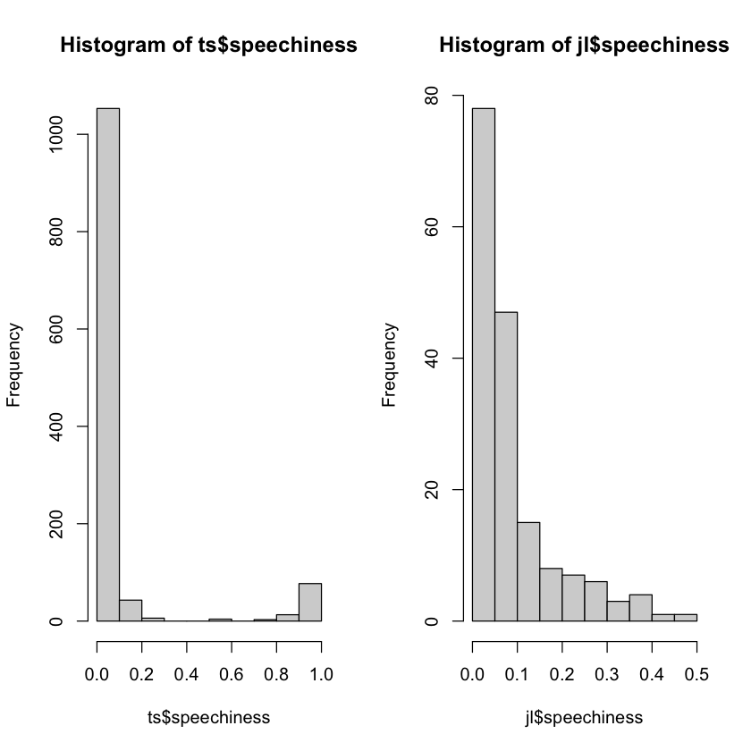

```r
par(mfrow = c(1, 2))
hist(ts$speechiness)
hist(jl$speechiness)
```

```r
summary(ts)
```

```
       X          artist_name           Valence        danceability
 Min.   :   1.0   Length:1199        Min.   :0.0383   Min.   :0.1750
 1st Qu.: 300.5   Class :character   1st Qu.:0.2580   1st Qu.:0.5280
 Median : 600.0   Mode  :character   Median :0.4190   Median :0.5960
 Mean   : 600.0                      Mean   :0.4232   Mean   :0.5908
 3rd Qu.: 899.5                      3rd Qu.:0.5585   3rd Qu.:0.6600
 Max.   :1199.0                      Max.   :0.9660   Max.   :0.8970
     energy          loudness        speechiness       acousticness
 Min.   :0.0639   Min.   :-17.932   Min.   :0.02310   Min.   :0.0000247
 1st Qu.:0.4130   1st Qu.: -9.843   1st Qu.:0.02970   1st Qu.:0.0170500
 Median :0.5990   Median : -7.138   Median :0.03550   Median :0.1220000
 Mean   :0.5710   Mean   : -7.758   Mean   :0.11445   Mean   :0.3175656
 3rd Qu.:0.7330   3rd Qu.: -5.413   3rd Qu.:0.05375   3rd Qu.:0.6840000
 Max.   :0.9500   Max.   : -1.953   Max.   :0.95700   Max.   :0.9830000
    liveness           tempo         track_name         album_name
 Min.   :0.02910   Min.   : 47.61   Length:1199        Length:1199
 1st Qu.:0.09925   1st Qu.: 95.89   Class :character   Class :character
 Median :0.11800   Median :119.04   Mode  :character   Mode  :character
 Mean   :0.16276   Mean   :120.92
 3rd Qu.:0.17950   3rd Qu.:141.98
 Max.   :0.93100   Max.   :208.92
 album_release_year
 Min.   :2006
 1st Qu.:2010
 Median :2014
 Mean   :2014
 3rd Qu.:2019
 Max.   :2021
```

```r
summary(jl)
```

```
       X        artist_name           Valence        danceability
 Min.   :1200   Length:170         Min.   :0.0784   Min.   :0.1830
 1st Qu.:1242   Class :character   1st Qu.:0.3227   1st Qu.:0.4430
 Median :1284   Mode  :character   Median :0.5005   Median :0.5400
 Mean   :1284                      Mean   :0.4908   Mean   :0.5288
 3rd Qu.:1327                      3rd Qu.:0.6512   3rd Qu.:0.6150
 Max.   :1369                      Max.   :0.9560   Max.   :0.7960
     energy          loudness        speechiness       acousticness
 Min.   :0.1320   Min.   :-15.663   Min.   :0.02550   Min.   :0.00177
 1st Qu.:0.4445   1st Qu.: -8.526   1st Qu.:0.03757   1st Qu.:0.15550
 Median :0.6120   Median : -6.886   Median :0.05745   Median :0.33750
 Mean   :0.5893   Mean   : -7.047   Mean   :0.09524   Mean   :0.41511
 3rd Qu.:0.7578   3rd Qu.: -5.454   3rd Qu.:0.10775   3rd Qu.:0.73175
 Max.   :0.9700   Max.   : -2.977   Max.   :0.46700   Max.   :0.95300
    liveness          tempo         track_name         album_name
 Min.   :0.0627   Min.   : 58.54   Length:170         Length:170
 1st Qu.:0.1052   1st Qu.: 87.30   Class :character   Class :character
 Median :0.1410   Median : 98.81   Mode  :character   Mode  :character
 Mean   :0.2413   Mean   :109.84
 3rd Qu.:0.2868   3rd Qu.:129.38
 Max.   :0.9910   Max.   :215.86
 album_release_year
 Min.   :2003
 1st Qu.:2008
 Median :2013
 Mean   :2013
 3rd Qu.:2018
 Max.   :2020
```

2. Write the null and alternative hypothesis for this test.

$H_0$: The average “speechiness” for Taylor Switt and John Legend is same.  
$H_A$: The average “speechiness” for Taylor Switt is larger than John Legend’s “speechiness.

3. Perform a t-test and state your results and non-technical conclusion.

```r
t.test(ts$speechiness, jl$speechiness, alt="greater")
```

```
    Welch Two Sample t-test

data:  ts$speechiness and jl$speechiness
t = 1.9578, df = 576.99, p-value = 0.02537
alternative hypothesis: true difference in means is greater than 0
95 percent confidence interval:
 0.003044749         Inf
sample estimates:
 mean of x  mean of y
0.11444837 0.09523882
```

4. What can you say about the confidence interval? (Interpret)

Since the confidence interval goes to infinity, we can conclude that the speechiness of taylor swift is bigger.

5. Perform a bootstrap test for ratio of means of “speechiness”, Find the 95% bootstrap percentile interval for the ratio of means and write your conclusion.

```r
set.seed(199823)
iter = 10000
boot_ts = numeric(length(ts$speechiness))
boot_jl = numeric(length(jl$speechiness))
for(i in 1:iter){
    boot_ts[i] = mean(sample(ts$speechiness,length(ts$speechiness),replace=TRUE))
    boot_jl[i] = mean(sample(jl$speechiness,length(jl$speechiness),replace=TRUE))
}
quantile(boot_ts/boot_jl,c(0.025,0.975))
```

**2.5%**

1.00647041708101

**97.5%**

1.45213014268467

6. What is the bootstrap estimate of the bias for the mean ratio?

```r
mean(boot_ts/boot_jl) - mean(ts$speechiness)/mean(jl$speechiness)
```

0.00661565798757935

7. Compare your results from part c) and part e).

## Problem 2: Hypothesis Testing-part 2

Data Science Question: Does “Valence” of the songs depends on the Artist?

Valence: A measure from 0.0 to 1.0 describing the musical positiveness conveyed by a track. Tracks with high valence sound more positive (e.g. happy, cheerful, euphoric), while tracks with low valence sound more negative (e.g. sad, depressed, angry).

1. Create a new variable with the name ” Valence_C” and add it to the “Artists” data set. Fill this variable with values “more positive”,“Moderate”,“more negative” according to the value of “Valence” such that 0.8-1 is “more positive”, 0.5-0.79 is “Moderate” and 0.0-0.49 is “more negative”.

```r
artists$Valence_C = ifelse(artists$Valence >= 0.8, "more positive", ifelse(artists$Valence >= 0.5, "Moderate", "more negative"))
```

2. Carry out an appropriate test to make an informed decision for the above data science question using this new created variable “Valence_C”. Don’t forget to Write the null and alternative hypothesis.

$H_0$: The valences of artists are the same. (The valences of artists are not dependent on the artists.)  
$H_A$: The valence of artists are not the same. (The valences of artists are dependent on the artists.)

```r
table(artists$artist_name, artists$Valence_C)
```

```
                 Moderate more negative more positive
  Beyonc\303\251      225           406            39
  John Legend          78            85             7
  Taylor Swift        389           757            53
```

```r
chisq.test(table(artists$artist_name, artists$Valence_C))
```

```
    Pearson's Chi-squared test

data:  table(artists$artist_name, artists$Valence_C)
X-squared = 14.163, df = 4, p-value = 0.006794
```

3. What is your conclusion?

4. With your experience, what is your opinion about the conclusion you made in part c?

Even though, it is statistically signiicant having a p value less than 0.05. There might be other variables that affecting the valence. This undermines the relationship the conclusion I made in part c but it can be reinforced by having more data points.